# p8105_hw1_xm2229_050120

Xiaoyue Ma

5/1/2020

Problem 1

This problem is intended to emphasize variable types and introduce coercion; some awareness of how R treats numeric, character, and factor variables is necessary for working with these data types in practice.

Create a data frame comprised of:

a random sample of size 8 from a standard Normal distribution a logical vector indicating whether elements of the sample are greater than 0 a character vector of length 8 a factor vector of length 8, with 3 different factor “levels” Try to take the mean of each variable in your dataframe. What works and what doesn’t?

In some cases, you can explicitly convert variables from one type to another. Write a code chunk that applies the as.numeric function to the logical, character, and factor variables (please show this chunk but not the output). What happens, and why? Does this help explain what happens when you try to take the mean?

In a second code chunk:

convert the logical vector to numeric, and multiply the random sample by the result convert the logical vector to a factor, and multiply the random sample by the result convert the logical vector to a factor and then convert the result to numeric, and multiply the random sample by the result

```r
library(tidyverse)
set.seed(1)

problem_1_df = tibble(
  random_sample = rnorm(8),
  Logical_vec = random_sample > 0,
  character_vec = c("hotdog", "milk", "bread", "bagel", "banana", "apple", "orange", "pear"),
  factor_vec = factor(c("red", "blue", "white", "red", "blue", "white","red", "blue"))
)

mean_rand_samp = mean(pull(problem_1_df, random_sample))
mean_log_vec = mean(pull(problem_1_df, Logical_vec))
mean_cha_vec = mean(pull(problem_1_df, character_vec))
mean_fac_vec = mean(pull(problem_1_df, factor_vec))
```

- Mean of the random sample in `problem_1_df` is 0.1314544
- Mean of the logical vector in `problem_1_df` is 0.625
- Mean of the character vector in `problem_1_df` is NA
- Mean of the factor vector in `problem_1_df` does not exist

```r
numr_log = as.numeric(pull(problem_1_df, Logical_vec))
numr_char = as.numeric(pull(problem_1_df, character_vec))
numr_fac = as.numeric(pull(problem_1_df, factor_vec))

multiple_logical_numeric = numr_log * pull(problem_1_df, random_sample)
multiple_logical_factor = as.factor(pull(problem_1_df, Logical_vec)) * pull(problem_1_df, random_sample)
multiple_logical_factor_numeric = as.numeric(as.factor(pull(problem_1_df, Logical_vec)))* pull(problem_1_df, random_sample)
```

Problem 2

This problem focuses the use of inline R code, plotting, and the behavior of ggplot for variables of different types.

Create a data frame comprised of: x: a random sample of size 500 from a standard Normal distribution y: a random sample of size 500 from a standard Normal distribution A logical vector indicating whether x + y > 1 A numeric vector created by coercing the above logical vector A factor vector created by coercing the above logical vector Write a short description of your vector using inline R code, including: * the size of the dataset (using nrow and ncol) * the mean, median, and standard deviation of x * the proportion of cases for which x + y > 1

Make a scatterplot of y vs x; color points using the logical variable (adding color = … inside of aes in your ggplot code should help). Make a second and third scatterplot that color points using the numeric and factor variables, respectively, and comment on the color scales.

Export your first scatterplot to your project directory using ggsave.

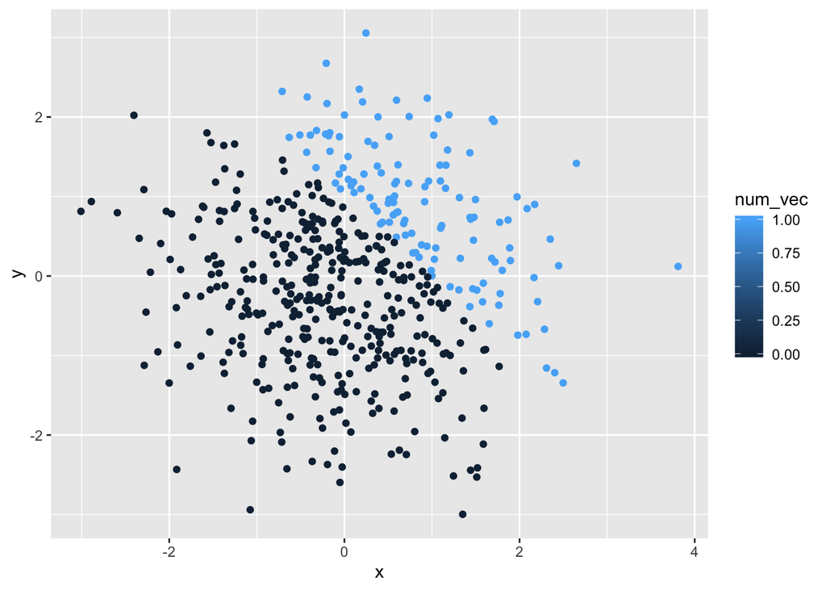

```r
problem_2_df = tibble(
  x = rnorm(500),
  y = rnorm(500),
  log_vec = x + y > 1,
  num_vec = as.numeric(log_vec),
  fac_vec = as.factor(log_vec)
)

plot_save = ggplot(problem_2_df, aes(x = x, y = y, color = log_vec)) + geom_point()
ggplot(problem_2_df, aes(x = x, y = y, color = num_vec)) + geom_point()
```

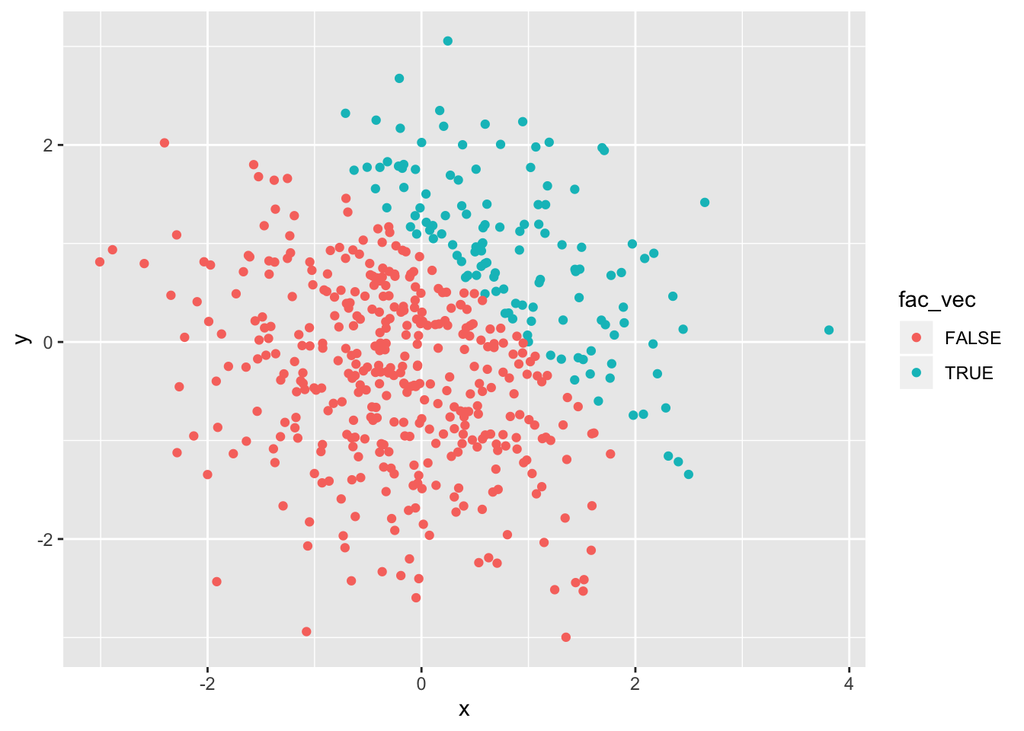

```r
ggplot(problem_2_df, aes(x = x, y = y, color = fac_vec)) + geom_point()
```

```r
ggsave(filename = "first_plot_save.png", plot = plot_save)
```